# Extract data by Timestamp

Pri Oberoi

August 9, 2016

Data from the Net Zero house includes measurements from various instruments around the house in one minute increments. Each variable, also called channels in NIST documentation, provides the readings from one instrument, and the instruments are grouped into subsystems like elec, Electrical, DHW.

This data also includes a few date/time variables like ‘TimeStampGPSTime’, which is the date and timestamp for each reading, ‘DayOfWeek’ and ‘TimeStampCount’. DayOfWeek is useful since computer controlled devices located in the house simulate the usage of a four-member family based on the day of the week.

This tutorial walks through filtering data based on time of day, and comparing channel readings by day of the week.

## Get the data you need

If you want to analyze net-zero data for specific subsystems, rather than data for the whole house, you can download the data from the [Net Zero data portal](http://commercedataservice.github.io/NZERTF/) and import it into R, or you can use the download link directly.

This is how you can analyze the channels (i.e. instrumentation data) in the Electrical subsystem:

```r
# load libraries
library(ggplot2) # plotting library

# get data
elec <- read.csv("https://s3.amazonaws.com/net-zero/2015-data-files/ElecEnergy.csv", header=TRUE, na.strings=c("NA", "NULL", "", " "))
```

Here are the first 20 variables included in the Electrical subsystem data. The nomenclature includes the name of the Sub-System and the name of the channel as SubSystem_SpecificChannel.

```r
names(elec)[1:20]
```

```
##  [1] "TimeStampGPSTime"
##  [2] "DayOfWeek"
##  [3] "TimeStampCount"
##  [4] "ElecEnergy_RPB1PlugsBaseAHeliodyneHXs"
##  [5] "ElecEnergy_RPB10PlugsOutdoorA"
##  [6] "ElecEnergy_RPB11PlugsOutsideEast"
##  [7] "ElecEnergy_RPB12PlugsOutdoorB"
##  [8] "ElecEnergy_RPB13PlugsDR"
##  [9] "ElecEnergy_RPB14PlugsBR4"
## [10] "ElecEnergy_RPB15PlugsEntryHall"
## [11] "ElecEnergy_RPB16PlugsLR"
## [12] "ElecEnergy_RPB17ClothesWasher"
## [13] "ElecEnergy_RPB18Dryer1of2"
## [14] "ElecEnergy_RPB19Dehumidifier"
## [15] "ElecEnergy_RPB2PlugsBaseB"
## [16] "ElecEnergy_RPB20Dryer2of2"
## [17] "ElecEnergy_RPB21HeatPump1of2"
## [18] "ElecEnergy_RPB22AHU21of2"
## [19] "ElecEnergy_RPB23HeatPump2of2"
## [20] "ElecEnergy_RPB24AHU22of2"
```

## Filter and visualize the data

Before we can visualize this data by date or time, we need to convert TimeStampGPSTime into a date/time format using strptime().

```r
# converts TimeStampGPSTime variable into date/time format (POSIXlt)
elec$TimeStampGPSTime <- strptime(elec$TimeStampGPSTime, "%Y-%m-%d %H:%M:%S")
```

Here is a sample of what that looks like:

```r
elec$TimeStampGPSTime[1:10]
```

```
##  [1] "1904-01-01 00:00:00 EST" "2015-02-01 05:02:50 EST"
##  [3] "2015-02-01 05:03:50 EST" "2015-02-01 05:04:50 EST"
##  [5] "2015-02-01 05:05:50 EST" "2015-02-01 05:06:50 EST"
##  [7] "2015-02-01 05:07:50 EST" "2015-02-01 05:08:50 EST"
##  [9] "2015-02-01 05:09:50 EST" "2015-02-01 05:10:50 EST"
```

Now we can choose a random day and look at what the refrigerator readings looked like by filtering our data using on TimeStampGPSTime:

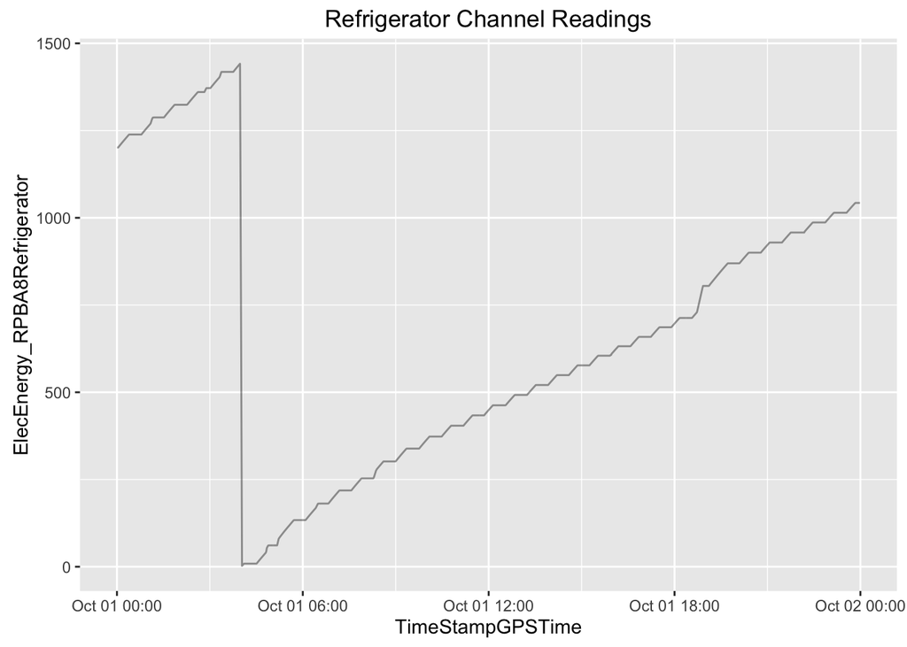

```r
ggplot(elec[elec$TimeStampGPSTime < '2015-10-02 00:00:00' & elec$TimeStampGPSTime > '2015-10-01 00:00:00',], aes(x = TimeStampGPSTime, y = ElecEnergy_RPBA8Refrigerator)) +
  geom_line(alpha = 0.4) +
  ggtitle("Refrigerator Channel Readings")
```

Or look at refrigerator readings for that day in comparison to the rest of the week:

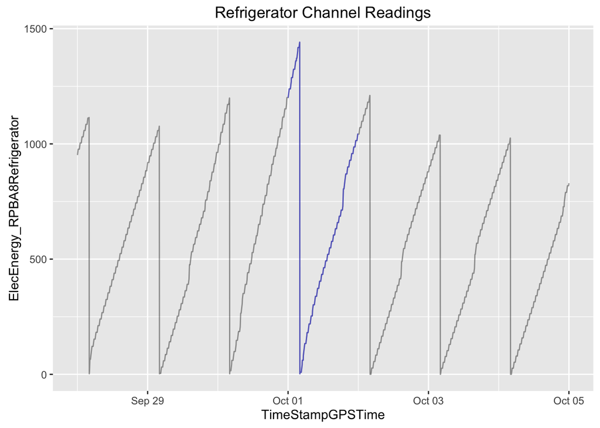

```r
ggplot(elec[elec$TimeStampGPSTime < '2015-10-05 00:00:00' & elec$TimeStampGPSTime > '2015-09-28 00:00:00',], aes(x = TimeStampGPSTime, y = ElecEnergy_RPBA8Refrigerator)) +
  geom_line(alpha = 0.4) +
  geom_line(data = elec[elec$TimeStampGPSTime < '2015-10-02 00:00:00' & elec$TimeStampGPSTime > '2015-10-01 00:00:00',], alpha = 0.4, color = "blue") +
  ggtitle("Refrigerator Channel Readings")
```